# Overdispersion’s Effect on Poisson Model Parameter Estimation

Jason Mouchawar

10/17/2017

### Background

Count models are a subset of discrete response regression models. Discrete models address non-negative integer responses. All count models aim to explain the number of occurrences, or counts, of an event. Counts are heteroskedastic, right skewed, and have a variance that increases with the mean of the distribution. The Poisson model is the basic count regression model from which many other variants are based on.

The Poisson’s main distributional assumption is that of equidispersion:

Where a discrete random variable Y ~ Poisson(μ) has mean

$E[Y] = μ$

and variance

$Var[Y] = μ$

In practice, this assumption of equidispersion is often violated resulting in extra-dispersion where the variance of the random count variable is not equal to the mean. Overdispersion occurs when the variance of the count variable is larger than the mean. In this case, the Poisson regression model is no longer suitable to appropriately model the data.

### Coverage Probability

When modelling overdispersed count data, the Poisson model will underestimate the standard errors of the model parameters. Confidence intervals are narrower than they should be.

The Monte Carlo simulation involved simulating count data or overdispersed count data, given the value of the overdispersion parameter, α. A Poisson model was then fit to the data and model estimates were computed. This process was simulated many times.

Coverage probability can be used to assess how overdispersion affects the estimation of Poisson model parameters. Coverage probability is calculated as the percentage of times that the designated value of 𝛽1 falls into the 95% confidence interval calculated in the simulation.

### Functions

The following helper functions are needed in the simulation and are defined in overdisp_sim.R:

dispersion(), data.sim(), poismodel.sim(), simulation()

### Simulation

Now, set global variables

```r
nobs = 1000
b0 = 1
b1 = .2
conf.level = .95
iterations = 500
alphavec = seq(0,5, by=.1)
```

And run the simulation.

The simulation will fit a Poisson Regression model to the data simulated from our helper functions using the glm function in R designating the family as Poisson. Save key estimated model statistics: estimate of 𝛽1, standard error of 𝛽1, lower and upper bounds of confidence intervals for 𝛽1, associated pvalues from one sample z tests, and the resulting overdispersion statistic

Simulate the data simulation / model fitting process iterations times to produce a data frame where each row is a vector of the saved estimated model parameters of a single iteration. A value we wish to examine is the coverage probability of the confidence intervals. Thus, each iteration adds an indicator (0,1) variable to the vector denoting if the confidence interval contains the true value of 𝛽1 as set by the global variables.

```r
cov.prob = NULL
for(i in 1:length(alphavec)){

  tempsim = simulation(iterations, alpha=alphavec[i])
  cov.prob[i] = sum(tempsim[,6])/dim(tempsim)[1]

}
```

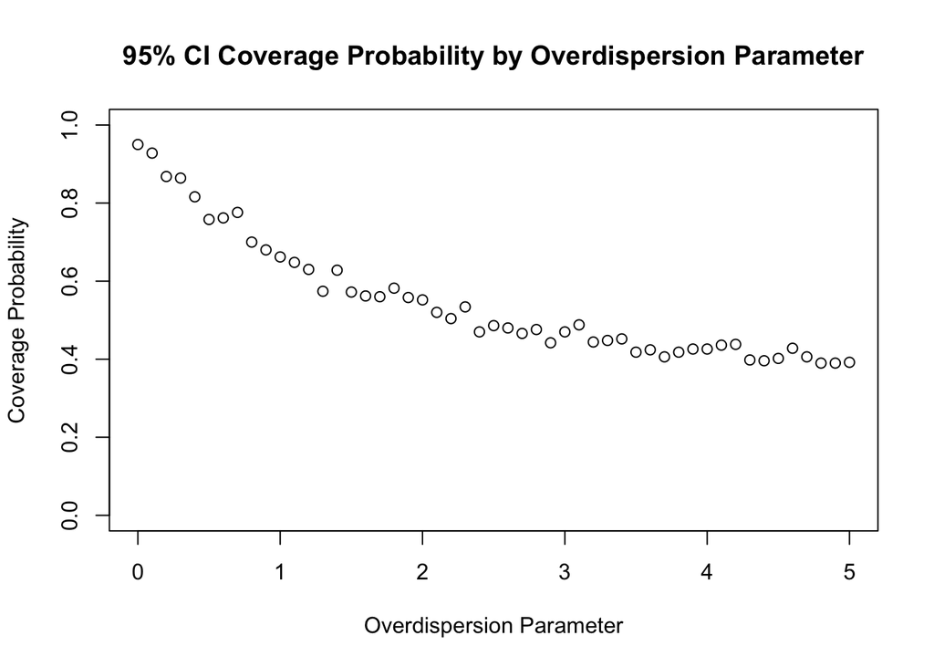

As the amount of overdispersion in the data increases, the coverage probability of these confidence intervals becomes dramatically worse. Low coverage probabilities are indicative of the underestimated standard errors. When there is no overdispersion in the simulated data (α = 0), fitting a Poisson model results in coverage probability about equal to our confidence level of 95%. As α increases, the coverage probability for a 95% confidence interval quickly drops to below 80%.

### Examples/Applications

#### Modeling Number of Marital Affairs

The first example we will explore is modelling the number of marital affairs. The response variable Naffairs is a non-negative integer count of the number of affairs reported by the participant. The data were previously modeled by Fair (1978) with a tobit model and Greene (2003) with a Poisson model.

```
##
## Call:
## glm(formula = naffairs ~ kids + avgmarr + hapavg + vryhap + notrel +
##     slghtrel + smerel + vryrel + yrsmarr, family = poisson, data = affairs)
##
## Deviance Residuals:
##     Min       1Q   Median       3Q      Max
## -3.6654  -1.4914  -1.1586  -0.7187   7.6221
##
## Coefficients:
##              Estimate Std. Error z value Pr(>|z|)
## (Intercept)  1.367194   0.135942  10.057  < 2e-16 ***
## kids        -0.036666   0.102774  -0.357    0.721
## avgmarr     -0.864141   0.103794  -8.326  < 2e-16 ***
## hapavg      -1.005101   0.084684 -11.869  < 2e-16 ***
## vryhap      -1.404440   0.100216 -14.014  < 2e-16 ***
## notrel      -0.663310   0.109811  -6.040 1.54e-09 ***
## slghtrel    -0.557667   0.111140  -5.018 5.23e-07 ***
## smerel      -1.392932   0.120811 -11.530  < 2e-16 ***
## vryrel      -1.436797   0.157752  -9.108  < 2e-16 ***
## yrsmarr      0.075456   0.007753   9.732  < 2e-16 ***
## ---
## Signif. codes:  0 '***' 0.001 '**' 0.01 '*' 0.05 '.' 0.1 ' ' 1
##
## (Dispersion parameter for poisson family taken to be 1)
##
##     Null deviance: 2925.5  on 600  degrees of freedom
## Residual deviance: 2337.9  on 591  degrees of freedom
## AIC: 2851.9
##
## Number of Fisher Scoring iterations: 7
```

```r
dispersion(poism)
```

```
## [1] 6.656375
```

The dispersion statistic (calculated by dividing the sum of the squared Pearson residuals by the model degrees of freedom) is evaluated at 6.65. Because this value is large than 1, it indicates overdispersion is present in the model.

We have fallen prey to a *Type 1 Error*. This occurs when we incorrectly conclude that a predictor in our model is significant (i.e. false positive). We attribute this abnormally high error rate to the underestimation of model parameters. To ammend this, fit a negative binomial model to predict number of affairs using the glm.nb() function from the MASS package.

```
##
## Call:
## glm.nb(formula = naffairs ~ kids + avgmarr + hapavg + vryhap +
##     notrel + slghtrel + smerel + vryrel + yrsmarr, data = affairs,
##     init.theta = 0.1452995709, link = log)
##
## Deviance Residuals:
##     Min       1Q   Median       3Q      Max
## -1.0853  -0.7907  -0.6798  -0.4518   2.7061
##
## Coefficients:
##             Estimate Std. Error z value Pr(>|z|)
## (Intercept)  1.13361    0.55419   2.046 0.040803 *
## kids         0.10154    0.32250   0.315 0.752879
## avgmarr     -1.02805    0.41931  -2.452 0.014216 *
## hapavg      -1.02369    0.36111  -2.835 0.004584 **
## vryhap      -1.42696    0.36845  -3.873 0.000108 ***
## notrel      -0.40056    0.45249  -0.885 0.376037
## slghtrel    -0.49063    0.46665  -1.051 0.293083
## smerel      -1.38016    0.45333  -3.044 0.002331 **
## vryrel      -1.65231    0.54184  -3.049 0.002293 **
## yrsmarr      0.08480    0.02636   3.217 0.001296 **
## ---
## Signif. codes:  0 '***' 0.001 '**' 0.01 '*' 0.05 '.' 0.1 ' ' 1
##
## (Dispersion parameter for Negative Binomial(0.1453) family taken to be 1)
##
##     Null deviance: 396.05  on 600  degrees of freedom
## Residual deviance: 340.31  on 591  degrees of freedom
## AIC: 1474.9
##
## Number of Fisher Scoring iterations: 1
##
##
##               Theta:  0.1453
##           Std. Err.:  0.0163
##
##  2 x log-likelihood:  -1452.8740
```

First, observe the standard errors of the coefficient estimates for each covariate. They are no longer being underestimated. Thus, some predictors are no longer significant. We can conduct a boundary likelihood ratio test of the log-likelihood of the negative binomial model against the log-likelihood of the Poisson model.

```r
LR = -2*logLik(poism) + nbm$twologlik
LR
```

```
## 'log Lik.' 1378.998 (df=10)
```

```r
pchisq(LR,1,lower.tail=F)/2
```

```
## 'log Lik.' 3.847478e-302 (df=10)
```

Testing the hypotheses

Ho: $α = 0$  
Ha: $α > 0$, where α is the value of the negative binomial overdispersion parameter

yields a $χ^2$ value with one degree of freedom of 1378.99 with a corresponding p-value less than 0.00001 indicating that a negative binomial model is significantly different from the Poisson model.

Further model selection is necessary to eliminate insignificant covariates.

```
##
## Call:
## glm.nb(formula = naffairs ~ avgmarr + hapavg + vryhap + smerel +
##     vryrel + yrsmarr, data = affairs, init.theta = 0.144199615,
##     link = log)
##
## Deviance Residuals:
##     Min       1Q   Median       3Q      Max
## -1.0882  -0.7883  -0.6931  -0.4557   2.5961
##
## Coefficients:
##             Estimate Std. Error z value Pr(>|z|)
## (Intercept)  0.78213    0.37643   2.078 0.037732 *
## avgmarr     -0.96801    0.41935  -2.308 0.020979 *
## hapavg      -1.05295    0.36178  -2.910 0.003609 **
## vryhap      -1.39969    0.36668  -3.817 0.000135 ***
## smerel      -1.02237    0.26822  -3.812 0.000138 ***
## vryrel      -1.30399    0.40073  -3.254 0.001138 **
## yrsmarr      0.09137    0.02253   4.055 5.02e-05 ***
## ---
## Signif. codes:  0 '***' 0.001 '**' 0.01 '*' 0.05 '.' 0.1 ' ' 1
##
## (Dispersion parameter for Negative Binomial(0.1442) family taken to be 1)
##
##     Null deviance: 393.98  on 600  degrees of freedom
## Residual deviance: 339.82  on 594  degrees of freedom
## AIC: 1470.1
##
## Number of Fisher Scoring iterations: 1
##
##
##               Theta:  0.1442
##           Std. Err.:  0.0162
##
##  2 x log-likelihood:  -1454.0780
```

Examination of the AIC of the reduced NB model gives evidence that it is better at modeling the number of marital affaris than the full NB model.

Other modeling approaches not included here: Zero-Inflated Model, Hurdle Model